# Tarea 8

# Tarea final

## Desarrolla una pregunta

Identifica una pregunta que se pueda responder con un modelo de aprendizaje máquina supervisado utilizando los datos del sitio web http://datosabiertos.presidencia.go.cr/home.

Puedes escoger datos de otras fuentes, pero tiene que ser sobre Costa y tienen que ser datos abiertos para que otra persona pueda reproducir el análisis.

## Prepara los datos

Ejecuta una exploración de datos para entender bien las variables que tienes disponibles y poder decidir cómo vas a responder tu pregunta. Es posible que tengas que cambiar la pregunta ligeramente (¡o mucho!), si es el caso describe el proceso y tu razonamiento para los cambios.

Al final decide por 2 métodos de aprendizaje automático que son relevantes para la preguntas que quieres hacer.

## Desarrollo modelos

Desarolla 2 modelos de aprendizaje automatizado (supervisado o no supervisado). Recuerda utilizar la metodologia CRISP-DM para implementar los modelos. Si buscas inspiración toma en cuenta que existe un repositorio de github https://github.com/SCRUG/DCC para tomar ideas sobre que modelos desarrollar con este tipo de datos.

Al final compara el desempeño de los dos modelos. Si es un método no supervisado el desempeño lo puedes describir como tu capacidad de responder la pregunta con una u otra (hay menos métricas y metodologías para hacer una comparación numérica).

### Calificación

- Desarrollo pregunta 25 %
  - Comprensión del problema
  - Desarrollo pregunta
- Analisis exloratorio 25 %
  - Comprensión de los datos
  - Decisión sobre metodos de analisis
- Modelado 25%
  - Preparación de los datos
  - Modelado
- Comparacion de modelos 25%
  - Evaluación de diferencias
  - Conclusiones

Librerias

```r
library(caTools)
library(rpart)
library(dplyr)
```

```r
library(ggplot2)
#..........Librerias de los modelos
library(rpart)
library(randomForest)
library(neuralnet)
library(e1071)
library(nnet)
library(ROCR)
```

**1.** Desarolle el Análisis del Problema

Se nos presenta un dataset del OIJ para año 2018, con delitos en diferentes provincia, clasificado por tipo de victima, entre otros atributos. Si realizamos un buen analisis a estos datos podremos detectar informacion que nos pueda ayudar a encontrar al posible que tan expuesto esta una persona a que sea una victima de un determinado delito, ya sea personal o hacía la propiedad, en nuestro caso hacía el vehiculo. Esta informacion puede ser valiosa por ejemplo para una empresa dedicada a la venta de articulos de defensa personal para determinar potenciales clientes.

Fuente del dataset: https://sitiooij.poder-judicial.go.cr/index.php/apertura/transparencia/estadisticas-policiales

**2.** Analisis exploratorio

Entendimiento de los Datos

```r
oij_dt <- read.csv(file = "oij_2018.csv", header = TRUE, sep = ",",strip.white = TRUE,
                    stringsAsFactors = FALSE)

#Eliminamos los datos sobre homicidios ya que solo nos interesan los datos de hurtos, robos, robos a vehiculos, tachas
oij_dt <- oij_dt[oij_dt$Delito!="HOMICIDIO",]
#Cambiamos los delitos a que sean unicamente ATAQUE PERSONAL o ATAQUE VEHICULO
oij_dt$Delito[oij_dt$Delito == "ASALTO"] <- "ATAQUE PERSONAL"
oij_dt$Delito[oij_dt$Delito == "HURTO"] <- "ATAQUE PERSONAL"
oij_dt$Delito[oij_dt$Delito == "ROBO"] <- "ATAQUE PERSONAL"
oij_dt$Delito[oij_dt$Delito == "ROBO DE VEHICULO"] <- "ATAQUE VEHICULO"
oij_dt$Delito[oij_dt$Delito == "TACHA DE VEHICULO"] <- "ATAQUE VEHICULO"

#Cambiamos las columnas que vamos a utilizar a factores
oij_dt$Delito <- as.factor(oij_dt$Delito)
oij_dt$Victima <- as.factor(oij_dt$Victima)
oij_dt$Edad <- as.factor(oij_dt$Edad)
oij_dt$Genero <- as.factor(oij_dt$Genero)
oij_dt$Provincia <- as.factor(oij_dt$Provincia)

head(oij_dt)
```

```
##            Delito   SubDelito      Fecha                Hora  Victima
## 1 ATAQUE PERSONAL ARMA BLANCA 2018-01-24 09:00:00 - 11:59:59  PERSONA
## 2 ATAQUE PERSONAL ARMA BLANCA 2018-02-02 21:00:00 - 23:59:59  PERSONA
## 3 ATAQUE PERSONAL ARMA BLANCA 2018-02-16 18:00:00 - 20:59:59  PERSONA
## 4 ATAQUE PERSONAL ARMA BLANCA 2018-02-23 18:00:00 - 20:59:59 VIVIENDA
## 5 ATAQUE PERSONAL ARMA BLANCA 2018-03-03 18:00:00 - 20:59:59  PERSONA
## 6 ATAQUE PERSONAL ARMA BLANCA 2018-03-17 18:00:00 - 20:59:59  PERSONA
##             SubVictima          Edad Genero Nacionalidad Provincia
## 1     PEATON [PERSONA] Mayor de edad HOMBRE   COSTA RICA  ALAJUELA
## 2     PEATON [PERSONA] Mayor de edad  MUJER   COSTA RICA  ALAJUELA
## 3     PEATON [PERSONA] Menor de edad  MUJER   COSTA RICA  ALAJUELA
## 4 NO APLICA [VIVIENDA] Mayor de edad HOMBRE   COSTA RICA  ALAJUELA
## 5     PEATON [PERSONA] Mayor de edad HOMBRE    NICARAGUA  ALAJUELA
## 6     PEATON [PERSONA] Mayor de edad HOMBRE   COSTA RICA  ALAJUELA
##       Canton Distrito  X
## 1   ALAJUELA          NA
## 2 SAN CARLOS          NA
## 3   ALAJUELA          NA
## 4   ALAJUELA          NA
## 5   ALAJUELA          NA
## 6 SAN CARLOS          NA
```

**3.** Observacion de corelaciones

- La mayor de ataque personales han sido en San Jose y es proporcionalmente más grande comparado a otras provincias.
- La mayoria de ataques personales se concentran en personas mayores de edad.
- Hay más casos de ataques personales y a vehiculo en hombres que mujeres, tomando en cuenta que ambas poblaciones son similares en Costa Rica.

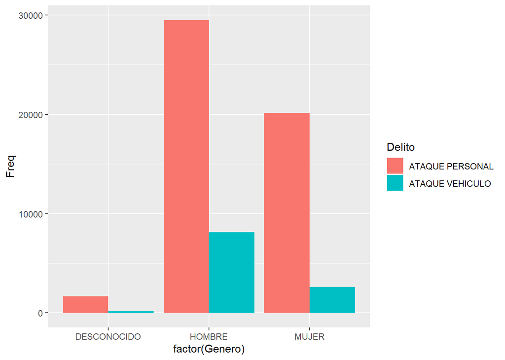

```r
tbl <- with(oij_dt, table(Delito, Genero))
ggplot(as.data.frame(tbl), aes(factor(Genero), Freq, fill = Delito)) +
  geom_col(position = 'dodge')
```

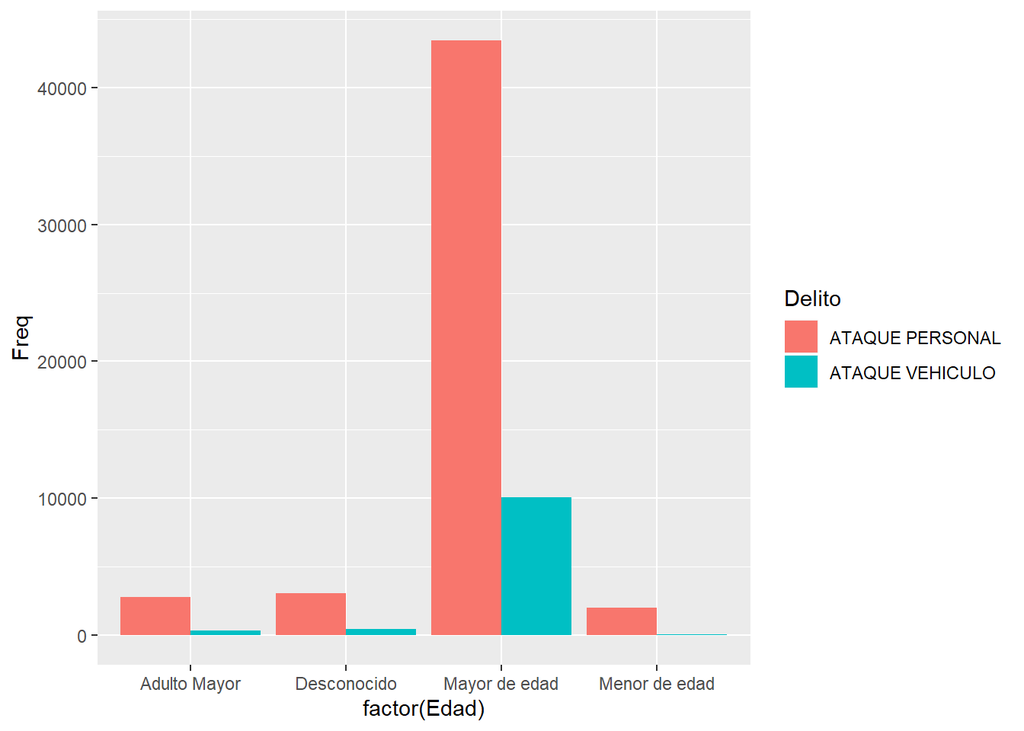

```r
tbl <- with(oij_dt, table(Delito, Edad))
ggplot(as.data.frame(tbl), aes(factor(Edad), Freq, fill = Delito)) +
  geom_col(position = 'dodge')
```

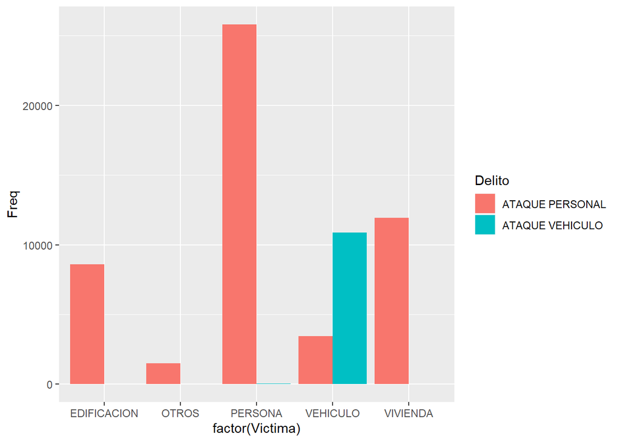

```r
tbl <- with(oij_dt, table(Delito, Victima))
ggplot(as.data.frame(tbl), aes(factor(Victima), Freq, fill = Delito)) +
  geom_col(position = 'dodge')
```

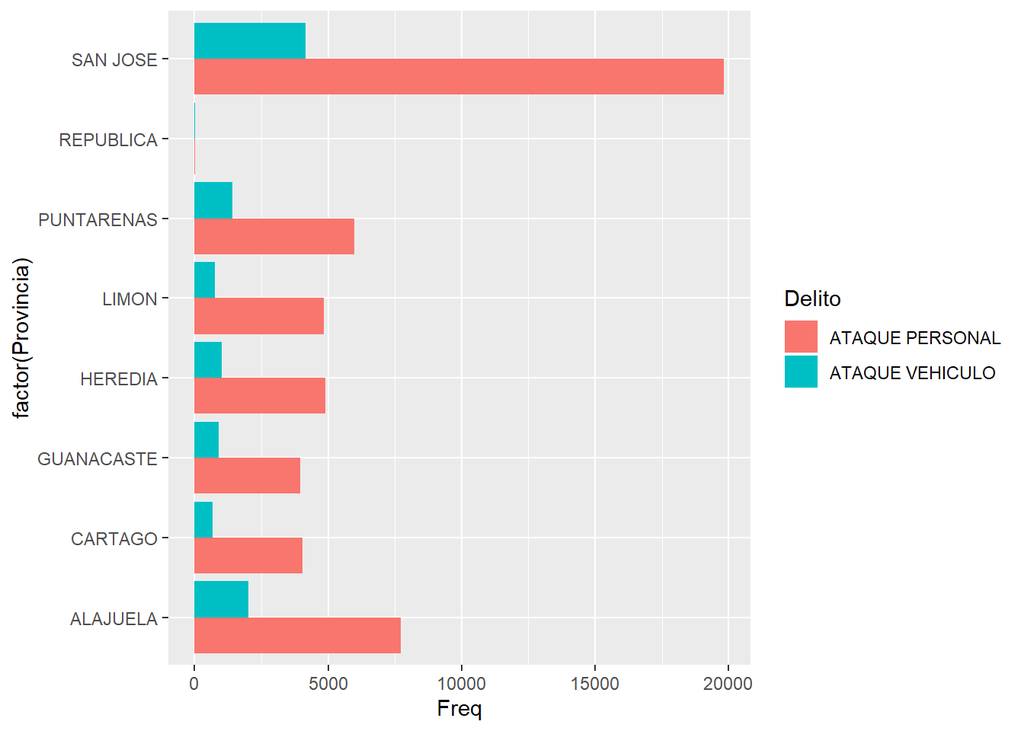

```r
tbl <- with(oij_dt, table(Delito, Provincia))
ggplot(as.data.frame(tbl), aes(factor(Provincia), Freq, fill = Delito)) +
  geom_col(position = 'dodge') +
  coord_flip()
```

```r
#Creamos los set de training y testing
set.seed(777)
splt <- sample.split(oij_dt$Delito, SplitRatio = 0.7)
oij_dt.entrenamiento <- oij_dt[splt,]
oij_dt.prueba <- oij_dt[!splt,]
```

```r
#ejecutamos los modelos
modelo.bosque <- randomForest(Delito ~ Victima + Edad + Genero + Provincia, data = oij_dt.entrenamiento)
modelo.regresion <- stats::glm(Delito ~ Victima + Edad + Genero + Provincia, data = oij_dt.entrenamiento, family = binomial)
```

**5.** Evaluacion de los modelos

```r
# Evaluamos las predicciones del random forest
modelo.bosque.predicciones <- predict(modelo.bosque, newdata = oij_dt.prueba, type = 'class')
modelo.bosque.evaluacion <- table(oij_dt.prueba$Delito, modelo.bosque.predicciones)##
modelo.bosque.performance <- performance(ROCR::prediction(c(modelo.bosque.predicciones), c(oij_dt.prueba$Delito)), measure = "auc")@y.values
print(modelo.bosque.evaluacion)
```

```
##                  modelo.bosque.predicciones
##                   ATAQUE PERSONAL ATAQUE VEHICULO
##   ATAQUE PERSONAL           14369            1023
##   ATAQUE VEHICULO              11            3270
```

```r
print(modelo.bosque.performance)
```

```
## [[1]]
## [1] 0.9650921
```

```r
# Curva ROC
prediccionesROC = ROCR::prediction(c(modelo.bosque.predicciones), c(oij_dt.prueba$Delito))
as.numeric(performance(prediccionesROC, "auc")@y.values)
```

```
## [1] 0.9650921
```

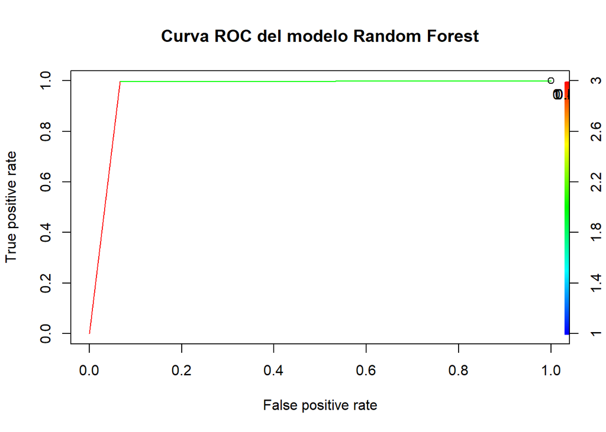

```r
plot(performance(prediccionesROC, "tpr", "fpr"),
colorize = T,
print.cutoffs.at = seq(0,1,by = 0.1),
text.adj = c(-0.2,1.7),
main = 'Curva ROC del modelo Random Forest')
```

```r
# Evaluamos las predicciones de la regresion logistica
modelo.regresion.predicciones <- predict(modelo.regresion, newdata = oij_dt.prueba, type = 'response')
modelo.regresion.evaluacion <- table(oij_dt.prueba$Delito, modelo.regresion.predicciones >= 0.7)
modelo.regresion.performance <- performance(ROCR::prediction(c(modelo.regresion.predicciones), c(oij_dt.prueba$Delito)), measure = "auc")@y.values
print(modelo.regresion.evaluacion)
```

```
##
##                   FALSE  TRUE
##   ATAQUE PERSONAL 14475   917
##   ATAQUE VEHICULO   223  3058
```

```r
print(modelo.regresion.performance)
```

```
## [[1]]
## [1] 0.9701831
```

```r
# Curva ROC
prediccionesROC = ROCR::prediction(c(modelo.regresion.predicciones), c(oij_dt.prueba$Delito))
as.numeric(performance(prediccionesROC, "auc")@y.values)
```

```
## [1] 0.9701831
```

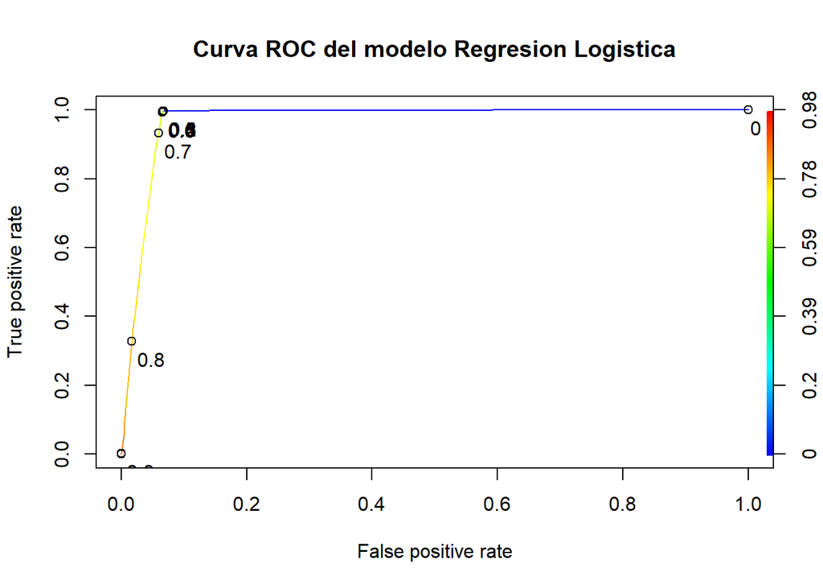

```r
plot(performance(prediccionesROC, "tpr", "fpr"),
colorize = T,
print.cutoffs.at = seq(0,1,by = 0.1),
text.adj = c(-0.2,1.7),
main = 'Curva ROC del modelo Regresion Logistica')
```

**6.** Conclusiones

- Ambos modelos de regresion y random forest obtubieron buenos resultados, aunque la regresion tiene una ligera ventaja.
- Si tomamos en cuenta que la poblacion de mujeres y hombres es muy similar en Costa Rica, los datos sugieren que es más probable que un hombre sea victima de un delito.
- Surge la pregunta de, cual es la real distincion entre un ataque personal y uno de vehiculo, por genero, edad y provincia, parece que no la hay, el factor determinanate parece ser la victima, evidentemente si la victima es un vehiculo, significa que es un ataque al vehiculo. Para esto entonces necesitamos más datos que nos ayuden a hacer una diferencia másnotable, tal ves si incluimos los datos de la fecha por mes, podríamos encontrar que en determinados meses las tachas a vehiculos son más probables.
- Los datos se prestan bastante para hacer analisis exploratorios y graficas para determinar que tipo de delitos son más comunes por edad, genero, provincia, fecha, subdelito es interesante porque se puede hacer analisis más enfocados. Al final es lo que a una empresa de seguridad la podría interesar, que tipo de servicios o productos puedo ofrecer a distintas poblaciones basado en la frecuencia de delito o subdelito para determinado factor.